# GeneAnnotation

Author

You

## Load Libraries

library(tidyverse) library(DT) library(knitr) install.packages(“broom”)

```r
## Load Libraries
library(tidyverse)
library(DT)
library(knitr)
library(seqinr)


native_data <- readRDS("/work/pi_jlb_umass_edu/blanchardlab/RNA_phages/RVMT_Zenodo_V4/Expanded_Contig_Set/native_data.rds")

contigs <- read_tsv(
  "/work/pi_jlb_umass_edu/blanchardlab/RNA_phages/RVMT_Zenodo_V4/Expanded_Contig_Set/viral_contigs_annotated_full.tsv"
)

colnames(contigs)
```

```
 [1] "Taxon_oid"     "Contig"        "ND"            "Contig length"
 [5] "Full_name"     "RCR90"         "Segmented"     "RID"
 [9] "Note"          "Genetic_Code"  "Type.hit"      "Hit.s."
[13] "RBS"           "RvANI90"       "AfLvl"         "Host_Evidence"
[17] "Host"          "BinID"         "Phylum"        "Class"
[21] "Order"         "Family"        "Genus"         "Novel"
[25] "Source"        "Set"           "Length"
```

```r
rdrp_contigs <- native_data |>
  left_join(contigs, by = "Full_name")


colnames(rdrp_contigs)
```

```
 [1] "ND.x"            "Full_name"       "RCR90.x"         "Segmented.x"
 [5] "RID.x"           "Note.x"          "Genetic_Code.x"  "Type.hit.x"
 [9] "Hit.s..x"        "RBS.x"           "RvANI90.x"       "AfLvl.x"
[13] "Host_Evidence.x" "Host.x"          "BinID.x"         "Phylum.x"
[17] "Class.x"         "Order.x"         "Family.x"        "Genus.x"
[21] "Novel.x"         "Source.x"        "Set.x"           "Length.x"
[25] "Site"            "Treatment"       "Subplot"         "Layer"
[29] "Inc"             "DataType"        "Taxon_oid"       "Contig"
[33] "ND.y"            "Contig length"   "RCR90.y"         "Segmented.y"
[37] "RID.y"           "Note.y"          "Genetic_Code.y"  "Type.hit.y"
[41] "Hit.s..y"        "RBS.y"           "RvANI90.y"       "AfLvl.y"
[45] "Host_Evidence.y" "Host.y"          "BinID.y"         "Phylum.y"
[49] "Class.y"         "Order.y"         "Family.y"        "Genus.y"
[53] "Novel.y"         "Source.y"        "Set.y"           "Length.y"
```

```r
dplyr::count(rdrp_contigs, Treatment)
```

```
# A tibble: 2 × 2
  Treatment     n
  <chr>     <int>
1 C          4530
2 H          3090
```

```r
rdrp_clean <- rdrp_contigs |>
  select(
    Full_name,
    RID = RID.x,
    ND = ND.x,
    Treatment,
    Site, Subplot, Layer,
    Order = Order.x,
    Family = Family.x,
    Genus = Genus.x,
    Phylum = Phylum.x,
    Novel = Novel.x,
    Segmented = Segmented.x,
    Length = Length.x,
    Host = Host.x,
    Host_Evidence = Host_Evidence.x,
    Contig,
    `Contig length`
  ) |>
  distinct()

colnames(rdrp_clean)
```

```
 [1] "Full_name"     "RID"           "ND"            "Treatment"
 [5] "Site"          "Subplot"       "Layer"         "Order"
 [9] "Family"        "Genus"         "Phylum"        "Novel"
[13] "Segmented"     "Length"        "Host"          "Host_Evidence"
[17] "Contig"        "Contig length"
```

```r
genome_counts <- rdrp_clean |>
  group_by(Treatment) |>
  summarize(UniqueGenomes = n_distinct(Contig))


genome_counts
```

```
# A tibble: 2 × 2
  Treatment UniqueGenomes
  <chr>             <int>
1 C                  4444
2 H                  3024
```

```r
# Genome richness per ND sample


genome_richness <- rdrp_clean |>
  group_by(ND, Treatment) |>
  summarize(GenomeRichness = n_distinct(Contig))
genome_richness
```

```
# A tibble: 7,435 × 3
# Groups:   ND [7,435]
   ND        Treatment GenomeRichness
   <chr>     <chr>              <int>
 1 ND_173510 H                      1
 2 ND_173511 H                      1
 3 ND_173512 H                      1
 4 ND_173513 H                      1
 5 ND_173514 H                      1
 6 ND_173515 H                      1
 7 ND_173516 H                      1
 8 ND_173517 H                      1
 9 ND_173518 H                      1
10 ND_173519 H                      2
# ℹ 7,425 more rows
```

# 1 Calulating VOTUs

create using RvANI90 (Average nucleotide identity at a 90 percent threshold Used to cluster contigs into species-like viral OTUs.) and RCR90 (Reciprocal coverage ratio Ensures contigs belong to the same genome / species)

RVMT’s rule: Contigs belong to the same VOTU if RvANI90 ≥ 90% AND RCR90 ≥ 90%. These metrics are calculated, need to be converted into cluster IDs

```r
viral <- readr::read_tsv("/work/pi_jlb_umass_edu/blanchardlab/RNA_phages/RVMT_Zenodo_V4/Expanded_Contig_Set/viral_contigs_annotated_full.tsv")


colnames(viral)
```

```
 [1] "Taxon_oid"     "Contig"        "ND"            "Contig length"
 [5] "Full_name"     "RCR90"         "Segmented"     "RID"
 [9] "Note"          "Genetic_Code"  "Type.hit"      "Hit.s."
[13] "RBS"           "RvANI90"       "AfLvl"         "Host_Evidence"
[17] "Host"          "BinID"         "Phylum"        "Class"
[21] "Order"         "Family"        "Genus"         "Novel"
[25] "Source"        "Set"           "Length"
```

# 2 Rebuilding VOTUs from RCR90 and RvANI90 (VOTU ID for each contig)

```r
viral_with_votu <- viral |>
  mutate(VOTU = paste0(RCR90, "__", RvANI90))


head(viral_with_votu$VOTU)
```

```
[1] "Rv4_003510__ANI90_0009179" "Rv4_003511__ANI90_0009178"
[3] "Rv4_003512__ANI90_0009177" "NA__ANI90_0009176"
[5] "Rv4_003514__ANI90_0009175" "Rv4_003515__ANI90_0009174"
```

# 3 attach VOTUs to joined RDRP and BW metadata table

```r
# these share Contig and ND
rdrp_clean
```

```
# A tibble: 7,620 × 18
   Full_name RID   ND    Treatment Site  Subplot Layer Order Family Genus Phylum
   <chr>     <chr> <chr> <chr>     <chr> <chr>   <chr> <chr> <chr>  <chr> <chr>
 1 33000224… Rv4_… ND_1… H         BW    32      O     Pico… Dicis… <NA>  Pisuv…
 2 33000224… Rv4_… ND_1… H         BW    32      O     Pico… Dicis… <NA>  Pisuv…
 3 33000224… Rv4_… ND_1… H         BW    32      O     Pico… f.004… <NA>  Pisuv…
 4 33000224… Rv4_… ND_1… H         BW    32      O     Pico… f.004… <NA>  Pisuv…
 5 33000224… Rv4_… ND_1… H         BW    32      O     Pico… f.000… <NA>  Pisuv…
 6 33000224… Rv4_… ND_1… H         BW    32      O     o.00… f.0217 <NA>  Kitri…
 7 33000224… Rv4_… ND_1… H         BW    32      O     Pico… f.002… <NA>  Pisuv…
 8 33000224… Rv4_… ND_1… H         BW    32      O     Pico… f.002… <NA>  Pisuv…
 9 33000224… Rv4_… ND_1… H         BW    32      O     o.00… f.0059 <NA>  Pisuv…
10 33000224… Rv4_… ND_1… H         BW    32      O     Tymo… f.019… <NA>  Kitri…
# ℹ 7,610 more rows
# ℹ 7 more variables: Novel <lgl>, Segmented <lgl>, Length <dbl>, Host <chr>,
#   Host_Evidence <chr>, Contig <chr>, `Contig length` <dbl>
```

```r
viral_with_votu
```

```
# A tibble: 348,778 × 28
    Taxon_oid Contig ND    `Contig length` Full_name RCR90 Segmented RID   Note
        <dbl> <chr>  <chr>           <dbl> <chr>     <chr> <lgl>     <chr> <chr>
 1 3300000305 33000… ND_4…            4517 33000003… Rv4_… NA        Rv4_… <NA>
 2 3300000305 33000… ND_4…            4057 33000003… Rv4_… NA        Rv4_… <NA>
 3 3300000305 33000… ND_4…            2732 33000003… Rv4_… NA        Rv4_… <NA>
 4 3300000305 33000… ND_4…            2372 33000003… <NA>  NA        Rv4_… <NA>
 5 3300000305 33000… ND_4…            4060 33000003… Rv4_… NA        Rv4_… <NA>
 6 3300000305 33000… ND_4…            3419 33000003… Rv4_… NA        Rv4_… <NA>
 7 3300000305 33000… ND_4…            4045 33000003… Rv4_… NA        Rv4_… <NA>
 8 3300000305 33000… ND_4…            3648 33000003… Rv4_… NA        Rv4_… <NA>
 9 3300000305 33000… ND_4…            3590 33000003… Rv4_… NA        Rv4_… <NA>
10 3300000305 33000… ND_4…            3604 33000003… <NA>  NA        Rv4_… <NA>
# ℹ 348,768 more rows
# ℹ 19 more variables: Genetic_Code <chr>, Type.hit <lgl>, Hit.s. <lgl>,
#   RBS <chr>, RvANI90 <chr>, AfLvl <chr>, Host_Evidence <chr>, Host <chr>,
#   BinID <chr>, Phylum <chr>, Class <chr>, Order <chr>, Family <chr>,
#   Genus <chr>, Novel <lgl>, Source <dbl>, Set <chr>, Length <dbl>, VOTU <chr>
```

```r
# join

votu_rdrp <- rdrp_clean |>
  left_join(
    viral_with_votu |> select(Contig, ND, VOTU),
    by = c("Contig", "ND")
  )


votu_rdrp |>
  select(Contig, ND, Treatment, VOTU) |>
  head(10)
```

```
# A tibble: 10 × 4
   Contig                       ND        Treatment VOTU
   <chr>                        <chr>     <chr>     <chr>
 1 3300022498_Ga0242644_1000002 ND_173510 H         Rv4_184006__ANI90_0064187
 2 3300022498_Ga0242644_1000003 ND_173511 H         Rv4_180652__ANI90_0064468
 3 3300022498_Ga0242644_1000004 ND_173512 H         Rv4_176631__ANI90_0064540
 4 3300022498_Ga0242644_1000005 ND_173513 H         Rv4_176632__ANI90_0064541
 5 3300022498_Ga0242644_1000006 ND_173514 H         Rv4_176633__ANI90_0062959
 6 3300022498_Ga0242644_1000007 ND_173515 H         Rv4_010336__ANI90_0016658
 7 3300022498_Ga0242644_1000008 ND_173516 H         Rv4_180664__ANI90_0064473
 8 3300022498_Ga0242644_1000009 ND_173517 H         Rv4_183112__ANI90_0044962
 9 3300022498_Ga0242644_1000010 ND_173518 H         Rv4_184382__ANI90_0063751
10 3300022498_Ga0242644_1000011 ND_173519 H         Rv4_178079__ANI90_0003966
```

```r
# head so reminder you wont see all
```

# 4 VOTU richness per treatment

```r
votu_richness_treat <- votu_rdrp |>
  group_by(Treatment) |>
  summarize(UniqueVOTUs = n_distinct(VOTU))

votu_richness_treat
```

```
# A tibble: 2 × 2
  Treatment UniqueVOTUs
  <chr>           <int>
1 C                2108
2 H                1258
```

Treatment/ UniqueVOTUs C / 2108  
H / 1258

Heated has less richness (fewer VOTUs)

# 5 VOTU richness per ND (sample based richness)

```r
votu_richness_nd <- votu_rdrp |>
  group_by(ND, Treatment) |>
  summarize(VOTUrichness = n_distinct(VOTU))

head(votu_richness_nd)
```

```
# A tibble: 6 × 3
# Groups:   ND [6]
  ND        Treatment VOTUrichness
  <chr>     <chr>            <int>
1 ND_173510 H                    1
2 ND_173511 H                    1
3 ND_173512 H                    1
4 ND_173513 H                    1
5 ND_173514 H                    1
6 ND_173515 H                    1
```

Not sure what to do about this yet- revisit ***

# 6 Genomes per VOTU per treatment

```r
genomes_per_votu_treat <- votu_rdrp |>
  group_by(Treatment, VOTU) |>
  summarize(GenomeCount = n_distinct(Contig), .groups = "drop")

head(genomes_per_votu_treat)
```

```
# A tibble: 6 × 3
  Treatment VOTU              GenomeCount
  <chr>     <chr>                   <int>
1 C         NA__ANI90_0004059           2
2 C         NA__ANI90_0004967           2
3 C         NA__ANI90_0005516           1
4 C         NA__ANI90_0005861           5
5 C         NA__ANI90_0006311           2
6 C         NA__ANI90_0006548           6
```

# 7 identify treatment-specific VOTUs (anything in both is ignored)

```r
genomes_per_votu_treat <- votu_rdrp |>
  group_by(Treatment, VOTU) |>
  summarize(GenomeCount = n_distinct(Contig), .groups = "drop")


votu_matrix <- genomes_per_votu_treat |>
  tidyr::pivot_wider(
    names_from = Treatment,
    values_from = GenomeCount,
    values_fill = 0
  )
```

Present in heated but absent in control

```r
heated_only_count <- votu_matrix |>
  filter(C == 0 & H > 0) |>
  nrow()

heated_only_count
```

```
[1] 888
```

888 VOTUs exclusive to heated soils

Present in controls but absent in heated

```r
control_only_count <- votu_matrix |>
  filter(H == 0 & C > 0) |>
  nrow()

control_only_count
```

```
[1] 1738
```

1738 VOTUs exclusive to control soils

## Genome counts by treatment, reshape into long format for plotting and then plot counts per VOTU

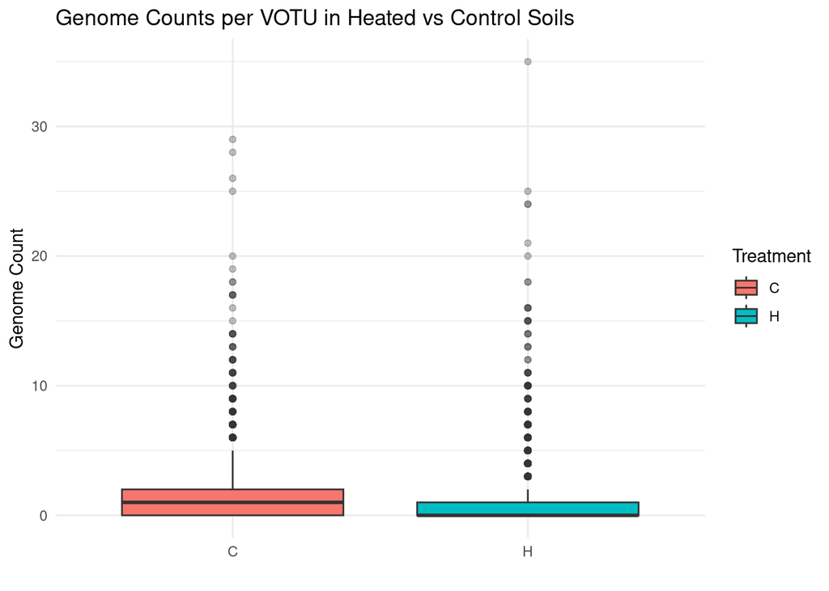

```r
votu_matrix <- genomes_per_votu_treat |>
  tidyr::pivot_wider(
    names_from = Treatment,
    values_from = GenomeCount,
    values_fill = 0
  )
votu_long <- votu_matrix |>
  pivot_longer(cols = c(C, H),
               names_to = "Treatment",
               values_to = "GenomeCount")
library(ggplot2)
ggplot(votu_long, aes(x = Treatment, y = GenomeCount, fill = Treatment)) +
  geom_boxplot(outlier.alpha = 0.3) +
  theme_minimal() +
  labs(
    title = "Genome Counts per VOTU in Heated vs Control Soils",
    x = "",
    y = "Genome Count"
  )
```

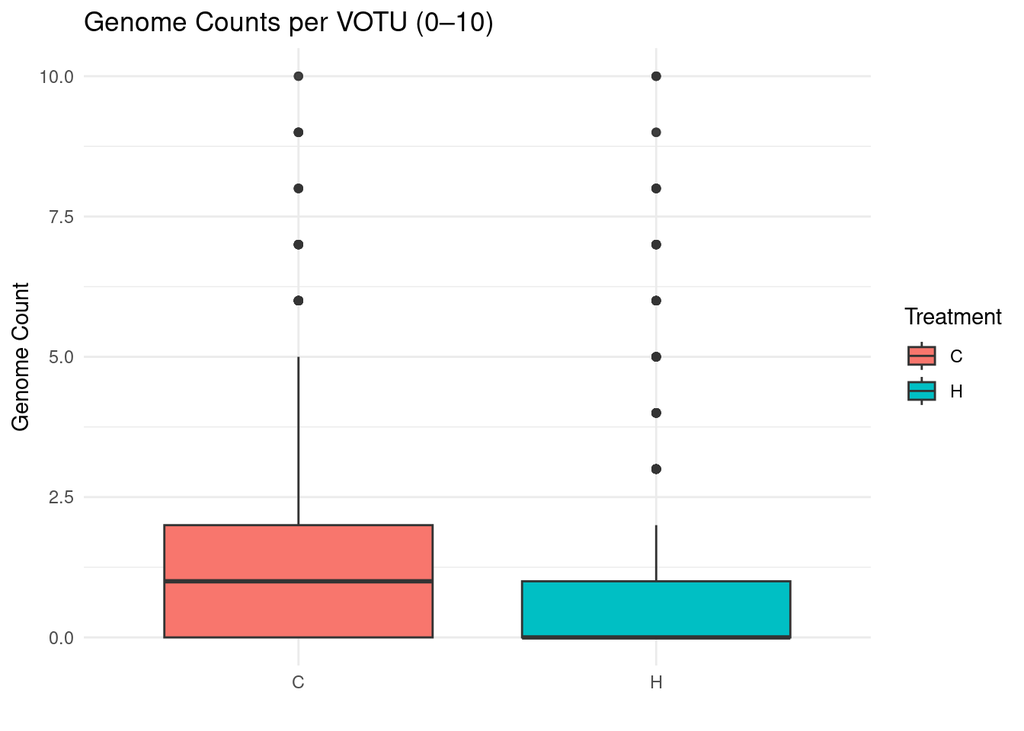

```r
ggplot(votu_long, aes(x = Treatment, y = GenomeCount, fill = Treatment)) +
  geom_boxplot(outlier.alpha = 0.3) +
  coord_cartesian(ylim = c(0, 10)) +
  theme_minimal() +
  labs(
    title = "Genome Counts per VOTU (0–10)",
    x = "",
    y = "Genome Count"
  )
```

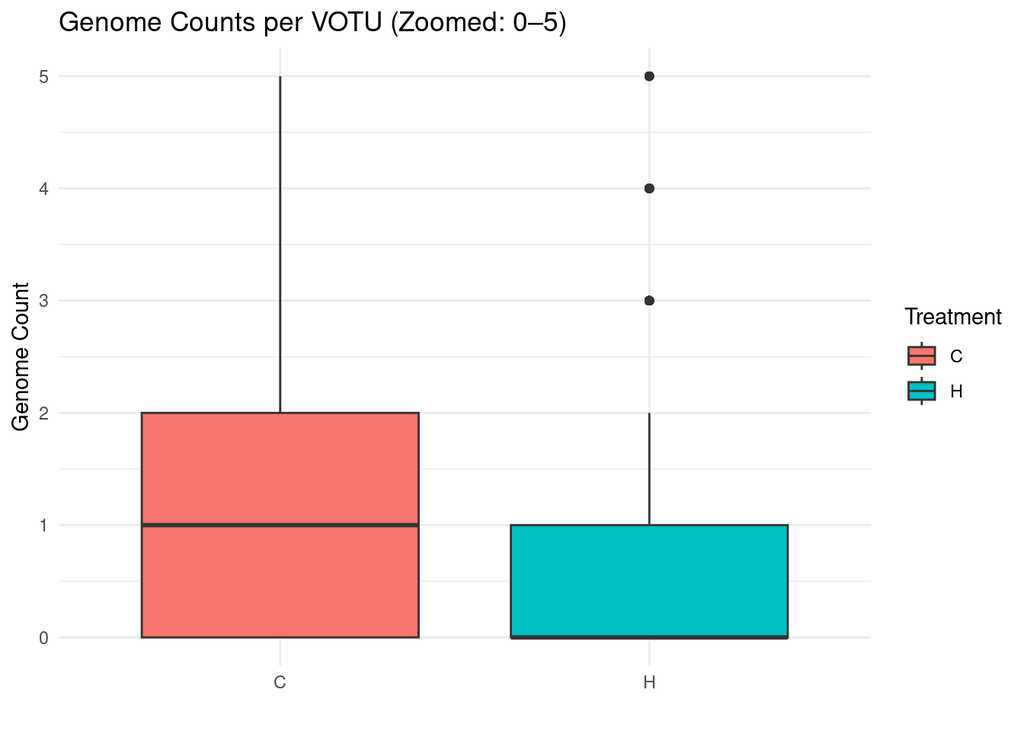

```r
# 1-5 zoom
ggplot(votu_long, aes(x = Treatment, y = GenomeCount, fill = Treatment)) +
  geom_boxplot(outlier.alpha = 0.3) +
  coord_cartesian(ylim = c(0, 5)) +
  theme_minimal() +
  labs(
    title = "Genome Counts per VOTU (Zoomed: 0–5)",
    x = "",
    y = "Genome Count"
  )
```

What this could mean :

Control VOTUs have more contigs per species.

# 8 add taxonomy to VOTUs

```r
votu_rdrp
```

```
# A tibble: 7,620 × 19
   Full_name RID   ND    Treatment Site  Subplot Layer Order Family Genus Phylum
   <chr>     <chr> <chr> <chr>     <chr> <chr>   <chr> <chr> <chr>  <chr> <chr>
 1 33000224… Rv4_… ND_1… H         BW    32      O     Pico… Dicis… <NA>  Pisuv…
 2 33000224… Rv4_… ND_1… H         BW    32      O     Pico… Dicis… <NA>  Pisuv…
 3 33000224… Rv4_… ND_1… H         BW    32      O     Pico… f.004… <NA>  Pisuv…
 4 33000224… Rv4_… ND_1… H         BW    32      O     Pico… f.004… <NA>  Pisuv…
 5 33000224… Rv4_… ND_1… H         BW    32      O     Pico… f.000… <NA>  Pisuv…
 6 33000224… Rv4_… ND_1… H         BW    32      O     o.00… f.0217 <NA>  Kitri…
 7 33000224… Rv4_… ND_1… H         BW    32      O     Pico… f.002… <NA>  Pisuv…
 8 33000224… Rv4_… ND_1… H         BW    32      O     Pico… f.002… <NA>  Pisuv…
 9 33000224… Rv4_… ND_1… H         BW    32      O     o.00… f.0059 <NA>  Pisuv…
10 33000224… Rv4_… ND_1… H         BW    32      O     Tymo… f.019… <NA>  Kitri…
# ℹ 7,610 more rows
# ℹ 8 more variables: Novel <lgl>, Segmented <lgl>, Length <dbl>, Host <chr>,
#   Host_Evidence <chr>, Contig <chr>, `Contig length` <dbl>, VOTU <chr>
```

```r
# adding taxonomy to VOTUs
votu_taxonomy <- votu_rdrp |>
  group_by(VOTU, Treatment) |>
  summarize(
    Orders = paste(unique(Order), collapse = "; "),
    Families = paste(unique(Family), collapse = "; "),
    Genera = paste(unique(Genus), collapse = "; "),
    GenomeCount = n_distinct(Contig),
    .groups = "drop"
  )


votu_taxonomy |> print(n = 20)
```

```
# A tibble: 3,366 × 6
   VOTU              Treatment Orders Families Genera GenomeCount
   <chr>             <chr>     <chr>  <chr>    <chr>        <int>
 1 NA__ANI90_0004059 C         NA     NA       NA               2
 2 NA__ANI90_0004967 C         NA     NA       NA               2
 3 NA__ANI90_0004967 H         NA     NA       NA               2
 4 NA__ANI90_0005209 H         NA     NA       NA               8
 5 NA__ANI90_0005516 C         NA     NA       NA               1
 6 NA__ANI90_0005625 H         NA     NA       NA               1
 7 NA__ANI90_0005861 C         NA     NA       NA               5
 8 NA__ANI90_0005861 H         NA     NA       NA               8
 9 NA__ANI90_0005983 H         NA     NA       NA               5
10 NA__ANI90_0006311 C         NA     NA       NA               2
11 NA__ANI90_0006311 H         NA     NA       NA               1
12 NA__ANI90_0006548 C         NA     NA       NA               6
13 NA__ANI90_0006548 H         NA     NA       NA               2
14 NA__ANI90_0007153 C         NA     NA       NA               1
15 NA__ANI90_0007153 H         NA     NA       NA               1
16 NA__ANI90_0007732 C         NA     NA       NA               6
17 NA__ANI90_0007732 H         NA     NA       NA              15
18 NA__ANI90_0016648 H         NA     NA       NA               1
19 NA__ANI90_0018239 C         NA     NA       NA               3
20 NA__ANI90_0018247 C         NA     NA       NA               1
# ℹ 3,346 more rows
```

Use this for Which viral orders dominate each treatment Which families are exclusive to heated or control soils How diverse each VOTU is (GenomeCount) Whether some VOTUs span both treatments

# saved joined dataset

```r
write_csv(votu_rdrp, "votu_rdrp_joined_Fall25.csv")
saveRDS(votu_rdrp, "votu_rdrp_joined_Fall25.rds")
```

# Add phylum to votu_taxonomy (1 per votu)

```r
votu_phylum <- votu_rdrp |>
  group_by(VOTU) |>
  summarize(
    Phylum = first(na.omit(Phylum)),
    .groups = "drop"
  )

votu_taxonomy2 <- votu_taxonomy |>
  left_join(votu_phylum, by = "VOTU")

votu_taxonomy2 |> print(n = 20)
```

```
# A tibble: 3,366 × 7
   VOTU              Treatment Orders Families Genera GenomeCount Phylum
   <chr>             <chr>     <chr>  <chr>    <chr>        <int> <chr>
 1 NA__ANI90_0004059 C         NA     NA       NA               2 Unclassified
 2 NA__ANI90_0004967 C         NA     NA       NA               2 Unclassified
 3 NA__ANI90_0004967 H         NA     NA       NA               2 Unclassified
 4 NA__ANI90_0005209 H         NA     NA       NA               8 Unclassified
 5 NA__ANI90_0005516 C         NA     NA       NA               1 Unclassified
 6 NA__ANI90_0005625 H         NA     NA       NA               1 Unclassified
 7 NA__ANI90_0005861 C         NA     NA       NA               5 Unclassified
 8 NA__ANI90_0005861 H         NA     NA       NA               8 Unclassified
 9 NA__ANI90_0005983 H         NA     NA       NA               5 Unclassified
10 NA__ANI90_0006311 C         NA     NA       NA               2 Unclassified
11 NA__ANI90_0006311 H         NA     NA       NA               1 Unclassified
12 NA__ANI90_0006548 C         NA     NA       NA               6 Unclassified
13 NA__ANI90_0006548 H         NA     NA       NA               2 Unclassified
14 NA__ANI90_0007153 C         NA     NA       NA               1 Unclassified
15 NA__ANI90_0007153 H         NA     NA       NA               1 Unclassified
16 NA__ANI90_0007732 C         NA     NA       NA               6 Unclassified
17 NA__ANI90_0007732 H         NA     NA       NA              15 Unclassified
18 NA__ANI90_0016648 H         NA     NA       NA               1 Unclassified
19 NA__ANI90_0018239 C         NA     NA       NA               3 Unclassified
20 NA__ANI90_0018247 C         NA     NA       NA               1 Unclassified
# ℹ 3,346 more rows
```

# phylum composition of VOTUs in heated vs control

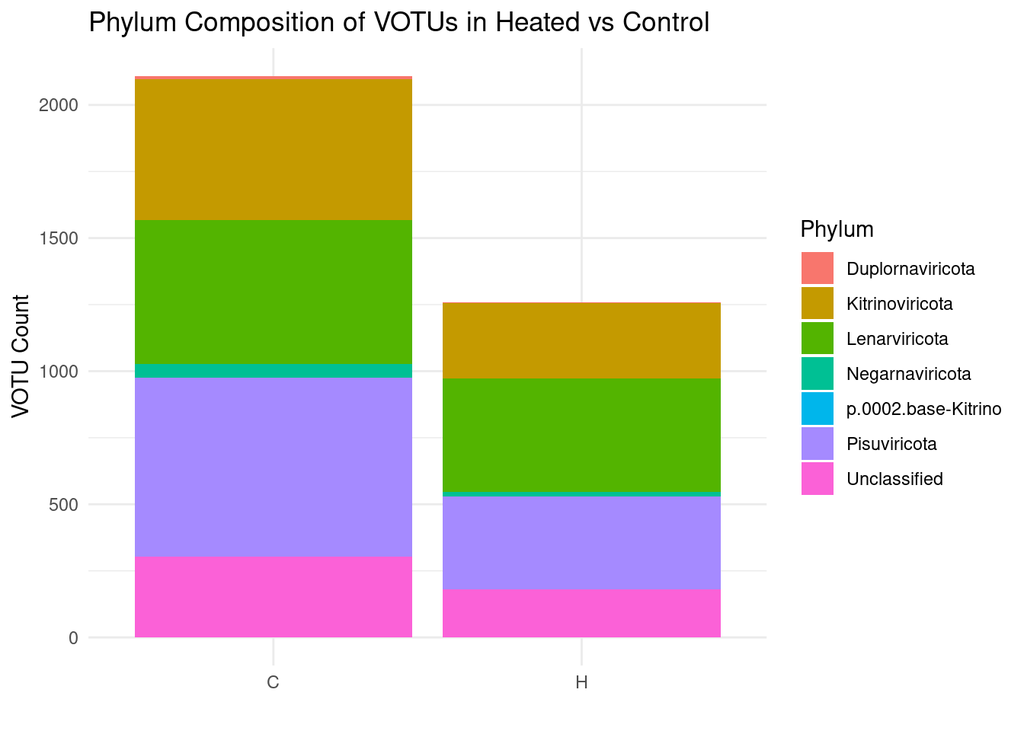

```r
ggplot(votu_taxonomy2, aes(x = Treatment, fill = Phylum)) +
  geom_bar(position = "stack") +
  theme_minimal() +
  labs(
    title = "Phylum Composition of VOTUs in Heated vs Control",
    x = "",
    y = "VOTU Count"
  )
```

You can see which phyla dominate each treatment

# Genome count distribution faceted by phylum

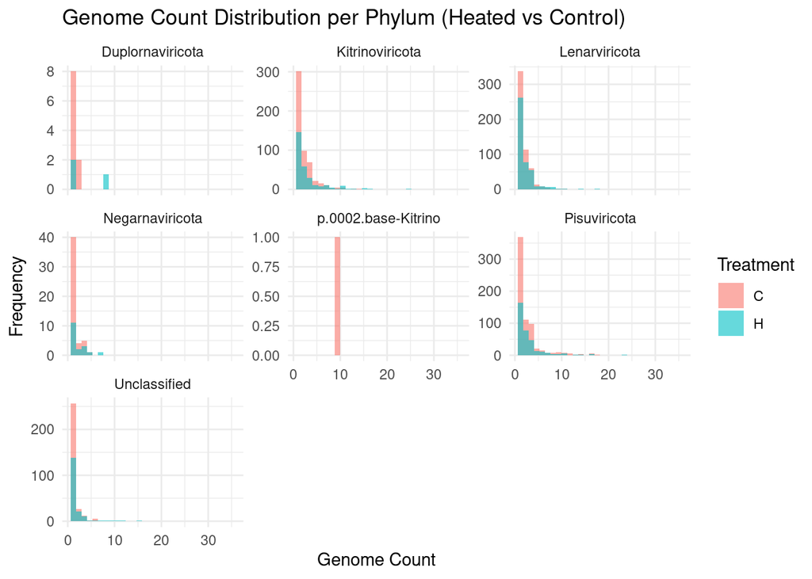

```r
ggplot(votu_taxonomy2, aes(x = GenomeCount, fill = Treatment)) +
  geom_histogram(bins = 30, alpha = 0.6, position = "identity") +
  facet_wrap(~ Phylum, scales = "free_y") +
  theme_minimal() +
  labs(
    title = "Genome Count Distribution per Phylum (Heated vs Control)",
    x = "Genome Count",
    y = "Frequency"
  )
```

# Median genomecount per phylum

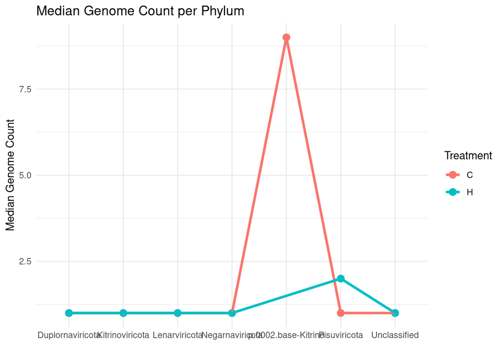

```r
med_gc <- votu_taxonomy2 |>
  group_by(Phylum, Treatment) |>
  summarize(
    median_gc = median(GenomeCount),
    .groups = "drop"
  )

ggplot(med_gc, aes(
  x = Phylum,
  y = median_gc,
  color = Treatment,
  group = Treatment
)) +
  geom_point(size = 3) +
  geom_line(size = 1.2) +
  theme_minimal() +
  labs(
    title = "Median Genome Count per Phylum",
    x = "",
    y = "Median Genome Count"
  )
```

# VOTU overlap plot

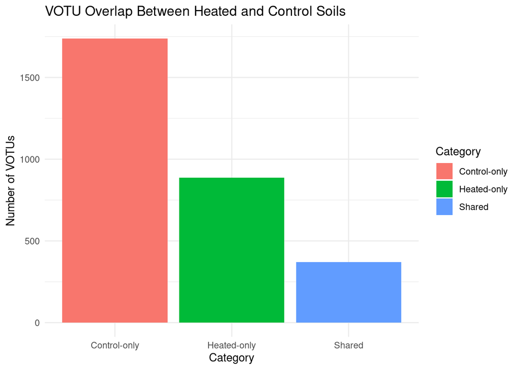

```r
votu_overlap <- tibble(
  Category = c("Heated-only", "Control-only", "Shared"),
  Count = c(
    sum(votu_matrix$C == 0 & votu_matrix$H > 0),
    sum(votu_matrix$H == 0 & votu_matrix$C > 0),
    sum(votu_matrix$C > 0 & votu_matrix$H > 0)
  )
)

ggplot(votu_overlap, aes(x = Category, y = Count, fill = Category)) +
  geom_col() +
  theme_minimal() +
  labs(
    title = "VOTU Overlap Between Heated and Control Soils",
    y = "Number of VOTUs"
  )
```